# Prosper Loan Data Exploration

## Preliminary Wrangling

```python
# import all packages and set plots to be embedded inline
import numpy as np
import pandas as pd
import matplotlib.pyplot as plt
import seaborn as sns
sns.set_style('darkgrid')

%matplotlib inline
```

```python
# load in the dataset into a pandas dataframe, print statistics
df = pd.read_csv('prosperLoanData.csv')
```

```python
# high-level overview
df.head(10)
```

|  | ListingKey | ListingNumber | ListingCreationDate | CreditGrade | Term | LoanStatus | ClosedDate | BorrowerAPR | BorrowerRate | LenderYield | ... | LP_ServiceFees | LP_CollectionFees | LP_GrossPrincipalLoss | LP_NetPrincipalLoss | LP_NonPrincipalRecoverypayments | PercentFunded | Recommendations | InvestmentFromFriendsCount | InvestmentFromFriendsAmount | Investors |
| --- | --- | --- | --- | --- | --- | --- | --- | --- | --- | --- | --- | --- | --- | --- | --- | --- | --- | --- | --- | --- | --- |
| 0 | 1021339766868145413AB3B | 193129 | 2007-08-26 19:09:29.263000000 | C | 36 | Completed | 2009-08-14 00:00:00 | 0.16516 | 0.1580 | 0.1380 | ... | -133.18 | 0.0 | 0.0 | 0.0 | 0.0 | 1.0 | 0 | 0 | 0.0 | 258 |
| 1 | 10273602499503308B223C1 | 1209647 | 2014-02-27 08:28:07.900000000 | NaN | 36 | Current | NaN | 0.12016 | 0.0920 | 0.0820 | ... | 0.00 | 0.0 | 0.0 | 0.0 | 0.0 | 1.0 | 0 | 0 | 0.0 | 1 |
| 2 | 0EE9337825851032864889A | 81716 | 2007-01-05 15:00:47.090000000 | HR | 36 | Completed | 2009-12-17 00:00:00 | 0.28269 | 0.2750 | 0.2400 | ... | -24.20 | 0.0 | 0.0 | 0.0 | 0.0 | 1.0 | 0 | 0 | 0.0 | 41 |
| 3 | 0EF5356002482715299901A | 658116 | 2012-10-22 11:02:35.010000000 | NaN | 36 | Current | NaN | 0.12528 | 0.0974 | 0.0874 | ... | -108.01 | 0.0 | 0.0 | 0.0 | 0.0 | 1.0 | 0 | 0 | 0.0 | 158 |
| 4 | 0F023589499656230C5E3E2 | 909464 | 2013-09-14 18:38:39.097000000 | NaN | 36 | Current | NaN | 0.24614 | 0.2085 | 0.1985 | ... | -60.27 | 0.0 | 0.0 | 0.0 | 0.0 | 1.0 | 0 | 0 | 0.0 | 20 |
| 5 | 0F05359734824199381F61D | 1074836 | 2013-12-14 08:26:37.093000000 | NaN | 60 | Current | NaN | 0.15425 | 0.1314 | 0.1214 | ... | -25.33 | 0.0 | 0.0 | 0.0 | 0.0 | 1.0 | 0 | 0 | 0.0 | 1 |
| 6 | 0F0A3576754255009D63151 | 750899 | 2013-04-12 09:52:56.147000000 | NaN | 36 | Current | NaN | 0.31032 | 0.2712 | 0.2612 | ... | -22.95 | 0.0 | 0.0 | 0.0 | 0.0 | 1.0 | 0 | 0 | 0.0 | 1 |
| 7 | 0F1035772717087366F9EA7 | 768193 | 2013-05-05 06:49:27.493000000 | NaN | 36 | Current | NaN | 0.23939 | 0.2019 | 0.1919 | ... | -69.21 | 0.0 | 0.0 | 0.0 | 0.0 | 1.0 | 0 | 0 | 0.0 | 1 |
| 8 | 0F043596202561788EA13D5 | 1023355 | 2013-12-02 10:43:39.117000000 | NaN | 36 | Current | NaN | 0.07620 | 0.0629 | 0.0529 | ... | -16.77 | 0.0 | 0.0 | 0.0 | 0.0 | 1.0 | 0 | 0 | 0.0 | 1 |
| 9 | 0F043596202561788EA13D5 | 1023355 | 2013-12-02 10:43:39.117000000 | NaN | 36 | Current | NaN | 0.07620 | 0.0629 | 0.0529 | ... | -16.77 | 0.0 | 0.0 | 0.0 | 0.0 | 1.0 | 0 | 0 | 0.0 | 1 |

10 rows × 81 columns

```python
# high-level overview
df.shape
```

```
(113937, 81)
```

```python
# high-level overview
df.info()
```

```
<class 'pandas.core.frame.DataFrame'>
RangeIndex: 113937 entries, 0 to 113936
Data columns (total 81 columns):
ListingKey                             113937 non-null object
ListingNumber                          113937 non-null int64
ListingCreationDate                    113937 non-null object
CreditGrade                            28953 non-null object
Term                                   113937 non-null int64
LoanStatus                             113937 non-null object
ClosedDate                             55089 non-null object
BorrowerAPR                            113912 non-null float64
BorrowerRate                           113937 non-null float64
LenderYield                            113937 non-null float64
EstimatedEffectiveYield                84853 non-null float64
EstimatedLoss                          84853 non-null float64
EstimatedReturn                        84853 non-null float64
ProsperRating (numeric)                84853 non-null float64
ProsperRating (Alpha)                  84853 non-null object
ProsperScore                           84853 non-null float64
ListingCategory (numeric)              113937 non-null int64
BorrowerState                          108422 non-null object
Occupation                             110349 non-null object
EmploymentStatus                       111682 non-null object
EmploymentStatusDuration               106312 non-null float64
IsBorrowerHomeowner                    113937 non-null bool
CurrentlyInGroup                       113937 non-null bool
GroupKey                               13341 non-null object
DateCreditPulled                       113937 non-null object
CreditScoreRangeLower                  113346 non-null float64
CreditScoreRangeUpper                  113346 non-null float64
FirstRecordedCreditLine                113240 non-null object
CurrentCreditLines                     106333 non-null float64
OpenCreditLines                        106333 non-null float64
TotalCreditLinespast7years             113240 non-null float64
OpenRevolvingAccounts                  113937 non-null int64
OpenRevolvingMonthlyPayment            113937 non-null float64
InquiriesLast6Months                   113240 non-null float64
TotalInquiries                         112778 non-null float64
CurrentDelinquencies                   113240 non-null float64
AmountDelinquent                       106315 non-null float64
```

[output cut: 31 more lines]

```
LP_CustomerPayments                    113937 non-null float64
LP_CustomerPrincipalPayments           113937 non-null float64
LP_InterestandFees                     113937 non-null float64
LP_ServiceFees                         113937 non-null float64
LP_CollectionFees                      113937 non-null float64
LP_GrossPrincipalLoss                  113937 non-null float64
LP_NetPrincipalLoss                    113937 non-null float64
LP_NonPrincipalRecoverypayments        113937 non-null float64
PercentFunded                          113937 non-null float64
Recommendations                        113937 non-null int64
InvestmentFromFriendsCount             113937 non-null int64
InvestmentFromFriendsAmount            113937 non-null float64
Investors                              113937 non-null int64
dtypes: bool(3), float64(50), int64(11), object(17)
memory usage: 68.1+ MB
```

```python
# descriptive statistics for numeric variables
df.describe()
```

|  | ListingNumber | Term | BorrowerAPR | BorrowerRate | LenderYield | EstimatedEffectiveYield | EstimatedLoss | EstimatedReturn | ProsperRating (numeric) | ProsperScore | ... | LP_ServiceFees | LP_CollectionFees | LP_GrossPrincipalLoss | LP_NetPrincipalLoss | LP_NonPrincipalRecoverypayments | PercentFunded | Recommendations | InvestmentFromFriendsCount | InvestmentFromFriendsAmount | Investors |
| --- | --- | --- | --- | --- | --- | --- | --- | --- | --- | --- | --- | --- | --- | --- | --- | --- | --- | --- | --- | --- | --- |
| count | 1.139370e+05 | 113937.000000 | 113912.000000 | 113937.000000 | 113937.000000 | 84853.000000 | 84853.000000 | 84853.000000 | 84853.000000 | 84853.000000 | ... | 113937.000000 | 113937.000000 | 113937.000000 | 113937.000000 | 113937.000000 | 113937.000000 | 113937.000000 | 113937.000000 | 113937.000000 | 113937.000000 |
| mean | 6.278857e+05 | 40.830248 | 0.218828 | 0.192764 | 0.182701 | 0.168661 | 0.080306 | 0.096068 | 4.072243 | 5.950067 | ... | -54.725641 | -14.242698 | 700.446342 | 681.420499 | 25.142686 | 0.998584 | 0.048027 | 0.023460 | 16.550751 | 80.475228 |
| std | 3.280762e+05 | 10.436212 | 0.080364 | 0.074818 | 0.074516 | 0.068467 | 0.046764 | 0.030403 | 1.673227 | 2.376501 | ... | 60.675425 | 109.232758 | 2388.513831 | 2357.167068 | 275.657937 | 0.017919 | 0.332353 | 0.232412 | 294.545422 | 103.239020 |
| min | 4.000000e+00 | 12.000000 | 0.006530 | 0.000000 | -0.010000 | -0.182700 | 0.004900 | -0.182700 | 1.000000 | 1.000000 | ... | -664.870000 | -9274.750000 | -94.200000 | -954.550000 | 0.000000 | 0.700000 | 0.000000 | 0.000000 | 0.000000 | 1.000000 |
| 25% | 4.009190e+05 | 36.000000 | 0.156290 | 0.134000 | 0.124200 | 0.115670 | 0.042400 | 0.074080 | 3.000000 | 4.000000 | ... | -73.180000 | 0.000000 | 0.000000 | 0.000000 | 0.000000 | 1.000000 | 0.000000 | 0.000000 | 0.000000 | 2.000000 |
| 50% | 6.005540e+05 | 36.000000 | 0.209760 | 0.184000 | 0.173000 | 0.161500 | 0.072400 | 0.091700 | 4.000000 | 6.000000 | ... | -34.440000 | 0.000000 | 0.000000 | 0.000000 | 0.000000 | 1.000000 | 0.000000 | 0.000000 | 0.000000 | 44.000000 |
| 75% | 8.926340e+05 | 36.000000 | 0.283810 | 0.250000 | 0.240000 | 0.224300 | 0.112000 | 0.116600 | 5.000000 | 8.000000 | ... | -13.920000 | 0.000000 | 0.000000 | 0.000000 | 0.000000 | 1.000000 | 0.000000 | 0.000000 | 0.000000 | 115.000000 |
| max | 1.255725e+06 | 60.000000 | 0.512290 | 0.497500 | 0.492500 | 0.319900 | 0.366000 | 0.283700 | 7.000000 | 11.000000 | ... | 32.060000 | 0.000000 | 25000.000000 | 25000.000000 | 21117.900000 | 1.012500 | 39.000000 | 33.000000 | 25000.000000 | 1189.000000 |

8 rows × 61 columns

```python
sum(df.duplicated())
```

```
0
```

```python
df.isna().sum()
```

```
ListingKey                                  0
ListingNumber                               0
ListingCreationDate                         0
CreditGrade                             84984
Term                                        0
LoanStatus                                  0
ClosedDate                              58848
BorrowerAPR                                25
BorrowerRate                                0
LenderYield                                 0
EstimatedEffectiveYield                 29084
EstimatedLoss                           29084
EstimatedReturn                         29084
ProsperRating (numeric)                 29084
ProsperRating (Alpha)                   29084
ProsperScore                            29084
ListingCategory (numeric)                   0
BorrowerState                            5515
Occupation                               3588
EmploymentStatus                         2255
EmploymentStatusDuration                 7625
IsBorrowerHomeowner                         0
CurrentlyInGroup                            0
GroupKey                               100596
DateCreditPulled                            0
CreditScoreRangeLower                     591
CreditScoreRangeUpper                     591
FirstRecordedCreditLine                   697
CurrentCreditLines                       7604
OpenCreditLines                          7604
                                        ...
TotalProsperLoans                       91852
TotalProsperPaymentsBilled              91852
OnTimeProsperPayments                   91852
ProsperPaymentsLessThanOneMonthLate     91852
ProsperPaymentsOneMonthPlusLate         91852
ProsperPrincipalBorrowed                91852
ProsperPrincipalOutstanding             91852
ScorexChangeAtTimeOfListing             95009
LoanCurrentDaysDelinquent                   0
LoanFirstDefaultedCycleNumber           96985
LoanMonthsSinceOrigination                  0
LoanNumber                                  0
LoanOriginalAmount                          0
LoanOriginationDate                         0
LoanOriginationQuarter                      0
MemberKey                                   0
MonthlyLoanPayment                          0
LP_CustomerPayments                         0
LP_CustomerPrincipalPayments                0
LP_InterestandFees                          0
LP_ServiceFees                              0
LP_CollectionFees                           0
LP_GrossPrincipalLoss                       0
LP_NetPrincipalLoss                         0
LP_NonPrincipalRecoverypayments             0
PercentFunded                               0
Recommendations                             0
InvestmentFromFriendsCount                  0
InvestmentFromFriendsAmount                 0
Investors                                   0
Length: 81, dtype: int64
```

```python
# Subset the dataframe by selecting features of interest
target_columns = ['Term', 'LoanStatus', 'BorrowerRate','LoanOriginalAmount','ListingCategory (numeric)','DelinquenciesLast7Years', 'StatedMonthlyIncome', 'TotalProsperLoans','LoanOriginationDate', 'ProsperRating (Alpha)',
        'EmploymentStatus','Recommendations','Investors']
```

```python
df2 = df[target_columns]
```

```python
# overview
df2.head(5)
```

|  | Term | LoanStatus | BorrowerRate | LoanOriginalAmount | ListingCategory (numeric) | DelinquenciesLast7Years | StatedMonthlyIncome | TotalProsperLoans | LoanOriginationDate | ProsperRating (Alpha) | EmploymentStatus | Recommendations | Investors |
| --- | --- | --- | --- | --- | --- | --- | --- | --- | --- | --- | --- | --- | --- |
| 0 | 36 | Completed | 0.1580 | 9425 | 0 | 4.0 | 3083.333333 | NaN | 2007-09-12 00:00:00 | NaN | Self-employed | 0 | 258 |
| 1 | 36 | Current | 0.0920 | 10000 | 2 | 0.0 | 6125.000000 | NaN | 2014-03-03 00:00:00 | A | Employed | 0 | 1 |
| 2 | 36 | Completed | 0.2750 | 3001 | 0 | 0.0 | 2083.333333 | NaN | 2007-01-17 00:00:00 | NaN | Not available | 0 | 41 |
| 3 | 36 | Current | 0.0974 | 10000 | 16 | 14.0 | 2875.000000 | NaN | 2012-11-01 00:00:00 | A | Employed | 0 | 158 |
| 4 | 36 | Current | 0.2085 | 15000 | 2 | 0.0 | 9583.333333 | 1.0 | 2013-09-20 00:00:00 | D | Employed | 0 | 20 |

```python
# descriptive statistics for numeric variables
df2.describe()
```

|  | Term | BorrowerRate | LoanOriginalAmount | ListingCategory (numeric) | DelinquenciesLast7Years | StatedMonthlyIncome | TotalProsperLoans | Recommendations | Investors |
| --- | --- | --- | --- | --- | --- | --- | --- | --- | --- |
| count | 113937.000000 | 113937.000000 | 113937.00000 | 113937.000000 | 112947.000000 | 1.139370e+05 | 22085.000000 | 113937.000000 | 113937.000000 |
| mean | 40.830248 | 0.192764 | 8337.01385 | 2.774209 | 4.154984 | 5.608026e+03 | 1.421100 | 0.048027 | 80.475228 |
| std | 10.436212 | 0.074818 | 6245.80058 | 3.996797 | 10.160216 | 7.478497e+03 | 0.764042 | 0.332353 | 103.239020 |
| min | 12.000000 | 0.000000 | 1000.00000 | 0.000000 | 0.000000 | 0.000000e+00 | 0.000000 | 0.000000 | 1.000000 |
| 25% | 36.000000 | 0.134000 | 4000.00000 | 1.000000 | 0.000000 | 3.200333e+03 | 1.000000 | 0.000000 | 2.000000 |
| 50% | 36.000000 | 0.184000 | 6500.00000 | 1.000000 | 0.000000 | 4.666667e+03 | 1.000000 | 0.000000 | 44.000000 |
| 75% | 36.000000 | 0.250000 | 12000.00000 | 3.000000 | 3.000000 | 6.825000e+03 | 2.000000 | 0.000000 | 115.000000 |
| max | 60.000000 | 0.497500 | 35000.00000 | 20.000000 | 99.000000 | 1.750003e+06 | 8.000000 | 39.000000 | 1189.000000 |

```python
df2.shape
```

```
(113937, 13)
```

```python
df2.isna().sum()
```

```
Term                             0
LoanStatus                       0
BorrowerRate                     0
LoanOriginalAmount               0
ListingCategory (numeric)        0
DelinquenciesLast7Years        990
StatedMonthlyIncome              0
TotalProsperLoans            91852
LoanOriginationDate              0
ProsperRating (Alpha)        29084
EmploymentStatus              2255
Recommendations                  0
Investors                        0
dtype: int64
```

```python
df2 = df2.dropna(subset=['ProsperRating (Alpha)']).reset_index()
```

```python
df2.isna().sum()
```

```
index                            0
Term                             0
LoanStatus                       0
BorrowerRate                     0
LoanOriginalAmount               0
ListingCategory (numeric)        0
DelinquenciesLast7Years          0
StatedMonthlyIncome              0
TotalProsperLoans            65056
LoanOriginationDate              0
ProsperRating (Alpha)            0
EmploymentStatus                 0
Recommendations                  0
Investors                        0
dtype: int64
```

```python
df2['LoanOriginationDate'] = pd.to_datetime(df2['LoanOriginationDate'])
```

```python
df2.info()
```

```
<class 'pandas.core.frame.DataFrame'>
RangeIndex: 84853 entries, 0 to 84852
Data columns (total 14 columns):
index                        84853 non-null int64
Term                         84853 non-null int64
LoanStatus                   84853 non-null object
BorrowerRate                 84853 non-null float64
LoanOriginalAmount           84853 non-null int64
ListingCategory (numeric)    84853 non-null int64
DelinquenciesLast7Years      84853 non-null float64
StatedMonthlyIncome          84853 non-null float64
TotalProsperLoans            19797 non-null float64
LoanOriginationDate          84853 non-null datetime64[ns]
ProsperRating (Alpha)        84853 non-null object
EmploymentStatus             84853 non-null object
Recommendations              84853 non-null int64
Investors                    84853 non-null int64
dtypes: datetime64[ns](1), float64(4), int64(6), object(3)
memory usage: 9.1+ MB
```

```python
df2['TotalProsperLoans'] = df2['TotalProsperLoans'].fillna(0)
```

```python
df2.isna().sum()
```

```
index                        0
Term                         0
LoanStatus                   0
BorrowerRate                 0
LoanOriginalAmount           0
ListingCategory (numeric)    0
DelinquenciesLast7Years      0
StatedMonthlyIncome          0
TotalProsperLoans            0
LoanOriginationDate          0
ProsperRating (Alpha)        0
EmploymentStatus             0
Recommendations              0
Investors                    0
dtype: int64
```

### What is the structure of your dataset?

> The dataset contains 113,937 loans with 81 features (including LoanOriginalAmount, BorrowerAPR, StatedMonthlyIncome, Term, ProsperRating (Alpha), EmploymentStatus and many others)!

### What is/are the main feature(s) of interest in your dataset?

> There are so many variables and I will try to figure out what features are best for predicting.

### What features in the dataset do you think will help support your investigation into your feature(s) of interest?

> I expect that the 13 features that I select in df will help to support the investigation.

'Term', 'LoanStatus', 'BorrowerRate','LoanOriginalAmount','ListingCategory (numeric)','DelinquenciesLast7Years', 'StatedMonthlyIncome', 'TotalProsperLoans','LoanOriginationDate', 'ProsperRating (Alpha)', 'EmploymentStatus','Recommendations','Investors'

## Univariate Exploration

```python
df3 = df2.copy()
```

```python
# set the default color and method to avoid duplicated code
def x_y_t(xL,yL,title):
    plt.title(title)
    plt.xlable(xL)
    plt.ylabel(yL)
base_color = sns.color_palette()[2]
```

### Loan Status

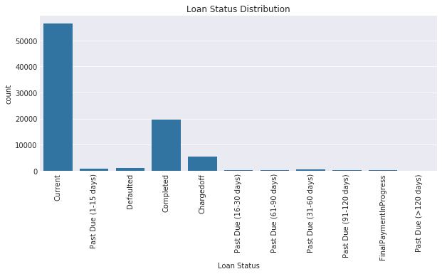

```python
# Checking loan status
plt.figure(figsize=[10, 4])
sns.countplot(data = df3, x = 'LoanStatus', color = base_color)
plt.title('Loan Status Distribution')
plt.xlabel('Loan Status')
plt.xticks(rotation = 90);
```

```python
order = df3['LoanStatus'].value_counts().index
```

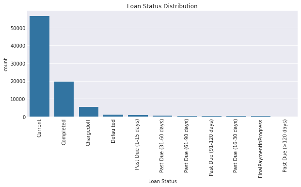

```python
# Ordering loan status
plt.figure(figsize=[10, 4])
sns.countplot(data = df3, x = 'LoanStatus', color = base_color, order = order)
plt.title('Loan Status Distribution')
plt.xlabel('Loan Status')
plt.xticks(rotation = 90);
```

The biggest part of the loans are current loans,past due loans are divided several groups based on the lenght of payment delay. Accordingly the second biggest group is completed loans and chargedoff compromise significant proportion and defaulted loans look very rare.

### Employment Status

```python
sorted_counts = df3['EmploymentStatus'].value_counts()
```

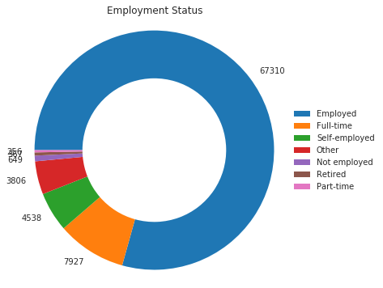

```python
# Checking Employment status
plt.figure(figsize=[8, 6])
plt.pie(sorted_counts,labels = sorted_counts, startangle = 180,
        counterclock = False, wedgeprops = {'width' : 0.4})

plt.title('Employment Status')
plt.legend(sorted_counts.index, bbox_to_anchor = (1.0, 0.5), loc = 6)
plt.axis('off')
plt.axis('square');
```

### Borrower Rate

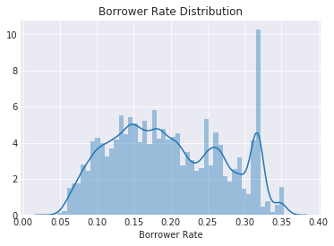

```python
sns.distplot(df3['BorrowerRate'])
plt.title('Borrower Rate Distribution')
plt.xlabel('Borrower Rate');
```

```python
df3['BorrowerRate'].describe()
```

```
count    84853.000000
mean         0.196022
std          0.074631
min          0.040000
25%          0.135900
50%          0.187500
75%          0.257400
max          0.360000
Name: BorrowerRate, dtype: float64
```

### Loan Original Amount

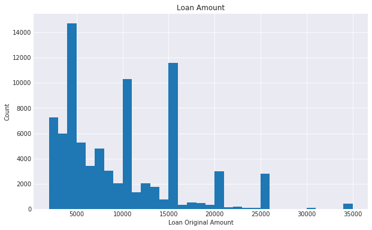

```python
# Checking Loan Original Amount
plt.figure(figsize=[10, 6])
bins = np.arange(2000, df3['LoanOriginalAmount'].max()+1000, 1000)
plt.hist(data = df3, x = 'LoanOriginalAmount', bins = bins)
plt.title('Loan Amount')
plt.xlabel('Loan Original Amount')
plt.ylabel('Count');
```

Amount that borrowed many times are 4500 , 10000 , 15000.

### Monthly Stated Income

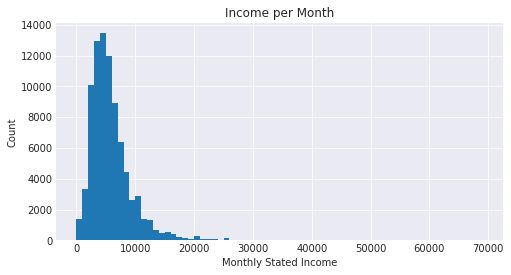

```python
# Checking Monthly Stated Income
plt.figure(figsize=[8, 4])
bins = np.arange(0, 70000, 1000)
plt.hist(data = df3, x = 'StatedMonthlyIncome', bins = bins)
plt.title('Income per Month')
plt.xlabel('Monthly Stated Income')
plt.ylabel('Count');
```

Distributin of Monthly Stated Income is very large range but still it is right screwed and most of the people's monthly income are under 20000.

### Discuss the distribution(s) of your variable(s) of interest. Were there any unusual points? Did you need to perform any transformations?

> Distributin of Monthly Stated Income is very large range but still it is right screwed.The majority of borrowers are employed and other categories are the small part of borrowers. Most of the loans are current loans.

### Of the features you investigated, were there any unusual distributions? Did you perform any operations on the data to tidy, adjust, or change the form of the data? If so, why did you do this?

> The majority of the loans are actually current loans. Our main goal is to define the driving factors of outcome of loan that is why, we are not interested in current loans.

## Bivariate Exploration

```python
df3.info()
```

```
<class 'pandas.core.frame.DataFrame'>
RangeIndex: 84853 entries, 0 to 84852
Data columns (total 14 columns):
index                        84853 non-null int64
Term                         84853 non-null int64
LoanStatus                   84853 non-null object
BorrowerRate                 84853 non-null float64
LoanOriginalAmount           84853 non-null int64
ListingCategory (numeric)    84853 non-null int64
DelinquenciesLast7Years      84853 non-null float64
StatedMonthlyIncome          84853 non-null float64
TotalProsperLoans            84853 non-null float64
LoanOriginationDate          84853 non-null datetime64[ns]
ProsperRating (Alpha)        84853 non-null object
EmploymentStatus             84853 non-null object
Recommendations              84853 non-null int64
Investors                    84853 non-null int64
dtypes: datetime64[ns](1), float64(4), int64(6), object(3)
memory usage: 9.1+ MB
```

```python
# Creating new columns as  loan rigination year, loan origination month and loan origination day
df3['LoanOriginationYear'] = df3['LoanOriginationDate'].dt.year
df3['LoanOriginationMonth'] = df3['LoanOriginationDate'].dt.month
df3['LoanOriginationDay'] = df3['LoanOriginationDate'].dt.day
```

```python
df3.head(5)
```

|  | index | Term | LoanStatus | BorrowerRate | LoanOriginalAmount | ListingCategory (numeric) | DelinquenciesLast7Years | StatedMonthlyIncome | TotalProsperLoans | LoanOriginationDate | ProsperRating (Alpha) | EmploymentStatus | Recommendations | Investors | LoanOriginationYear | LoanOriginationMonth | LoanOriginationDay |
| --- | --- | --- | --- | --- | --- | --- | --- | --- | --- | --- | --- | --- | --- | --- | --- | --- | --- |
| 0 | 1 | 36 | Current | 0.0920 | 10000 | 2 | 0.0 | 6125.000000 | 0.0 | 2014-03-03 | A | Employed | 0 | 1 | 2014 | 3 | 3 |
| 1 | 3 | 36 | Current | 0.0974 | 10000 | 16 | 14.0 | 2875.000000 | 0.0 | 2012-11-01 | A | Employed | 0 | 158 | 2012 | 11 | 1 |
| 2 | 4 | 36 | Current | 0.2085 | 15000 | 2 | 0.0 | 9583.333333 | 1.0 | 2013-09-20 | D | Employed | 0 | 20 | 2013 | 9 | 20 |
| 3 | 5 | 60 | Current | 0.1314 | 15000 | 1 | 0.0 | 8333.333333 | 0.0 | 2013-12-24 | B | Employed | 0 | 1 | 2013 | 12 | 24 |
| 4 | 6 | 36 | Current | 0.2712 | 3000 | 1 | 0.0 | 2083.333333 | 0.0 | 2013-04-18 | E | Employed | 0 | 1 | 2013 | 4 | 18 |

### Loan Origination Year vs Loan Original Amount

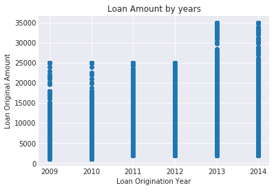

```python
plt.scatter(data = df3, x = 'LoanOriginationYear', y = 'LoanOriginalAmount')
plt.title('Loan Amount by years')
plt.xlabel('Loan Origination Year')
plt.ylabel('Loan Original Amount');
```

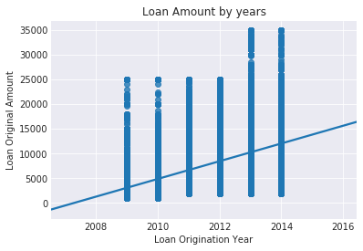

```python
sns.regplot(data = df3, x = 'LoanOriginationYear', y = 'LoanOriginalAmount' )
plt.title('Loan Amount by years')
plt.xlabel('Loan Origination Year')
plt.ylabel('Loan Original Amount');
```

As it shown in the aerly years the borrowed amount was less , the regplot shows that the loan amount is inclined to increase year by year.

### Borrower Rate vs Loan Origination Year

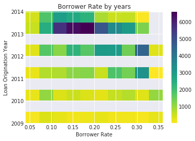

```python
plt.hist2d(data = df3, x = 'BorrowerRate', y = 'LoanOriginationYear', cmin=2, cmap='viridis_r')
plt.colorbar()
plt.title('Borrower Rate by years')
plt.xlabel('Borrower Rate')
plt.ylabel('Loan Origination Year');
```

The highest borrower rate was experienced on 2009, 2010 and 2011

### Employment Status vs Borrower Rate

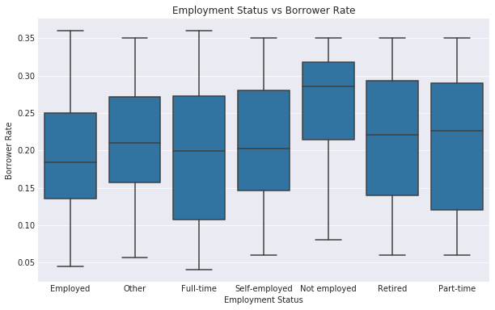

```python
plt.figure(figsize = [10, 6])
base_color = sns.color_palette()[0]
sns.boxplot(data=df3, x='EmploymentStatus', y='BorrowerRate', color=base_color)
plt.title('Employment Status vs Borrower Rate')
plt.xlabel('Employment Status')
plt.ylabel('Borrower Rate');
```

### Loan Status vs Borrower Rate

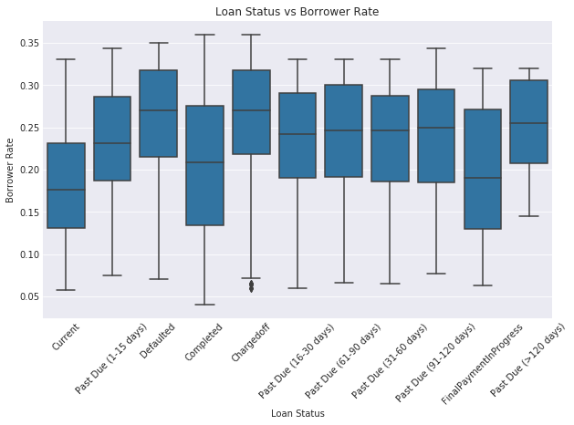

```python
plt.figure(figsize = [10, 6])
base_color = sns.color_palette()[0]
sns.boxplot(data=df3, x='LoanStatus', y='BorrowerRate', color=base_color)
plt.title('Loan Status vs Borrower Rate')
plt.xlabel('Loan Status')
plt.ylabel('Borrower Rate')
plt.xticks(rotation=45);
```

### Loan Original Amount vs Borrower Rate

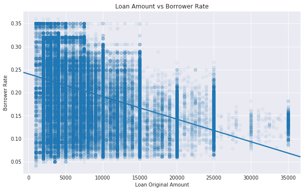

```python
plt.figure(figsize = [10, 6])
sns.regplot(data = df3, x = 'LoanOriginalAmount', y = 'BorrowerRate', scatter_kws={'alpha':0.05})
plt.title('Loan Amount vs Borrower Rate')
plt.xlabel('Loan Original Amount')
plt.ylabel('Borrower Rate');
```

The Borrower Rate decrease with the increase of loan amount. As a result, the borrower rate is negatively correlated with loan amount.

### Did you observe any interesting relationships between the other features (not the main feature(s) of interest)?

> There is a interaction between Loan Origination Year and Loan Original Amount. As it shown in the aerly years the borrowed amount was less , the regplot shows that the loan amount is inclined to increase year by year.

## Multivariate Exploration

```python
# Creating a sample for further implementation
np.random.seed(2018)
sample = np.random.choice(df.shape[0], 5000, replace = False)
df_subset = df.loc[sample]
```

### Employment Status and Loan Original Amount vs Loan Status

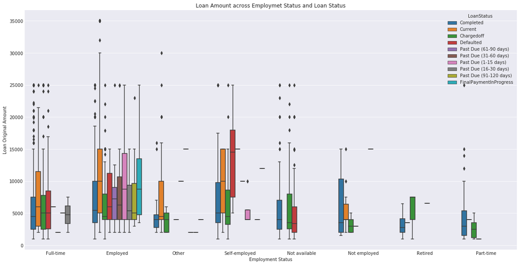

```python
plt.figure(figsize = [20, 10])
sns.boxplot(data = df_subset, x = 'EmploymentStatus', y = 'LoanOriginalAmount', hue = 'LoanStatus')
plt.title('Loan Amount across Employmet Status and Loan Status')
plt.xlabel('Employment Status')
plt.ylabel('Loan Original Amount');
```

### Prosper Rating (Alpha) and BorrowerAPR vs Term

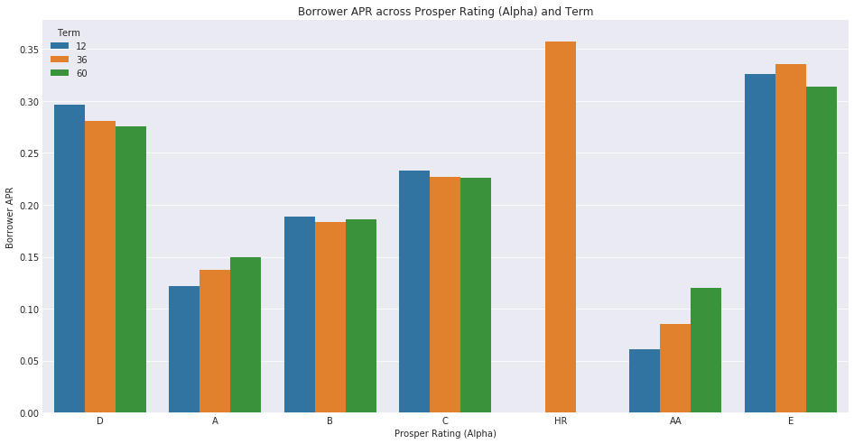

```python
plt.figure(figsize = [16, 8])
sns.barplot(data = df_subset, x = 'ProsperRating (Alpha)', y = 'BorrowerAPR', hue = 'Term', errwidth = 0)
plt.title('Borrower APR across Prosper Rating (Alpha) and Term')
plt.xlabel('Prosper Rating (Alpha)')
plt.ylabel('Borrower APR');
```

```python
# Convert ProsperRating into ordered categorical types
order = ['HR','E','D','C','B','A','AA']
ordered_var = pd.api.types.CategoricalDtype(ordered = True,
                                    categories = order)
df_subset['ProsperRating (Alpha)'] = df_subset['ProsperRating (Alpha)'].astype(ordered_var)
```

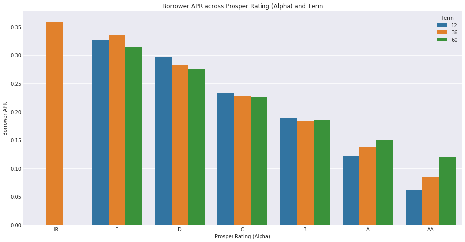

```python
plt.figure(figsize = [16, 8])
sns.barplot(data = df_subset, x = 'ProsperRating (Alpha)', y = 'BorrowerAPR', hue = 'Term',order = order, errwidth = 0)
plt.title('Borrower APR across Prosper Rating (Alpha) and Term')
plt.xlabel('Prosper Rating (Alpha)')
plt.ylabel('Borrower APR');
```

### Numerical Category variables

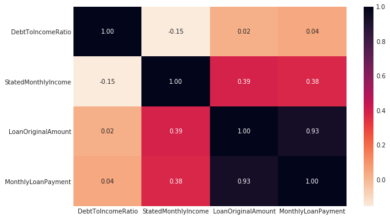

```python
plt.figure(figsize = [10, 6])
df_stats = ['DebtToIncomeRatio','StatedMonthlyIncome', 'LoanOriginalAmount', 'MonthlyLoanPayment']
sns.heatmap(df_subset[df_stats].corr(), cmap = 'rocket_r', annot = True, fmt = '.2f');
```

The plot shows that , logically, there is a high positive correlation between loan original amount and monthly loan payment. On the other side, there is negative correlation between debt to income ratio and monthly income. The correlation is almost zero among debt to income ratio and loan original amount and monthly loan payment.